# Mapping Assignment

Maggy Critchlow

4/18/2020

## Required Packages

```r
library(ggplot2)
library(dplyr)
library(raster)
library(rgdal)
library(sf)
library(ggrepel)
```

## Mount Baker Elevation

### Overview of Data Set

Using “GDALinfo”, we can see that this raster file is in UTM, rather than lat/long measurements, is in meter units, and has a 5x5 m resolution. This is necessary information in order to pick the best projection, and also to ensure all of our data is in consistent units.

```r
GDALinfo("data/mtbDEM.tif")
```

```
## rows        409
## columns     628
## bands       1
## lower left origin.x        596210.7
## lower left origin.y        5411132
## res.x       5
## res.y       5
## ysign       -1
## oblique.x   0
## oblique.y   0
## driver      GTiff
## projection  +proj=utm +zone=10 +ellps=GRS80 +towgs84=0,0,0,0,0,0,0 +units=m
## +no_defs
## file        data/mtbDEM.tif
## apparent band summary:
##    GDType hasNoDataValue NoDataValue blockSize1 blockSize2
## 1 Float32           TRUE    -3.4e+38          3        628
## apparent band statistics:
##       Bmin     Bmax Bmean Bsd
## 1 826.4308 1689.369   NaN NaN
## Metadata:
## AREA_OR_POINT=Area
```

```r
mtbDEM <- raster("data/mtbDEM.tif")
summary(mtbDEM)
```

```
##            mtbDEM
## Min.     827.0312
## 1st Qu. 1220.7845
## Median  1303.8369
## 3rd Qu. 1415.4481
## Max.    1689.2083
## NA's       0.0000
```

This gives us some useful information about our data. In order to use ggplot to make the map, this raster needs to be put into a data frame. The structure command provides a way to double check that this worked properly.

```r
mtbDEM_df <- as.data.frame(mtbDEM, xy = TRUE)
str(mtbDEM_df)
```

```
## 'data.frame':    256852 obs. of  3 variables:
##  $ x     : num  596213 596218 596223 596228 596233 ...
##  $ y     : num  5413175 5413175 5413175 5413175 5413175 ...
##  $ mtbDEM: num  1373 1371 1369 1366 1363 ...
```

### Basic Map of Mt Baker Elevation

With the data now in the data frame format, it’s easy to make a simple map using ggplot2.

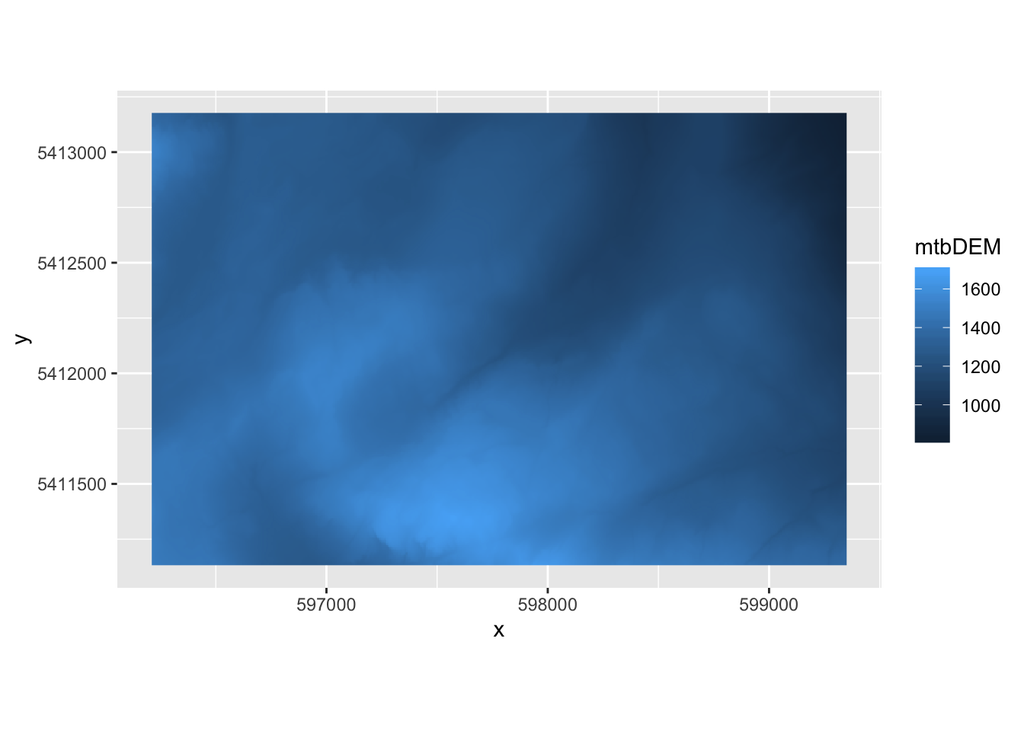

```r
ggplot() +
  geom_raster(data = mtbDEM_df , aes(x = x, y = y, fill = mtbDEM)) +
  coord_quickmap(xlim = NULL, ylim = NULL, expand = TRUE,
                 clip = "on") + coord_fixed()
```

This graph does display the elevation at each coordinate, but that’s about all it does well. Luckily, there’s a few things that can be changed to make it more useful. First, instead of the continuous elevation which is messy and hard to interpret, I’ll create categories. The difference between the maximum and minimum elevations is approximately 863 m. If we want each shade on the map to represent a 100m range of elevations, we can use 9 bins (the closest whole number to 8.63 bins). This grouping can be achieved using dplyr’s “mutate” command.

```r
mtbDEM_df <- mtbDEM_df %>% mutate(fct_elevation = cut(mtbDEM, breaks = 9))
```

## New and Improved Mt Baker Map

This is the map with the terrain colors and the elevation showing as a discrete variable rather than continuous. The legend shows the elevation ranges corresponding to each color. In improving this map, I also cleandc up the empty space between the map edge and the axes, removed the distracting grid lines on the background, and relabeled the axes and the main and legend titles.

```r
terrain.colors(9)
```

```
## [1] "#00A600FF" "#3EBB00FF" "#8BD000FF" "#E6E600FF" "#E8C32EFF" "#EBB25EFF"
## [7] "#EDB48EFF" "#F0C9C0FF" "#F2F2F2FF"
```

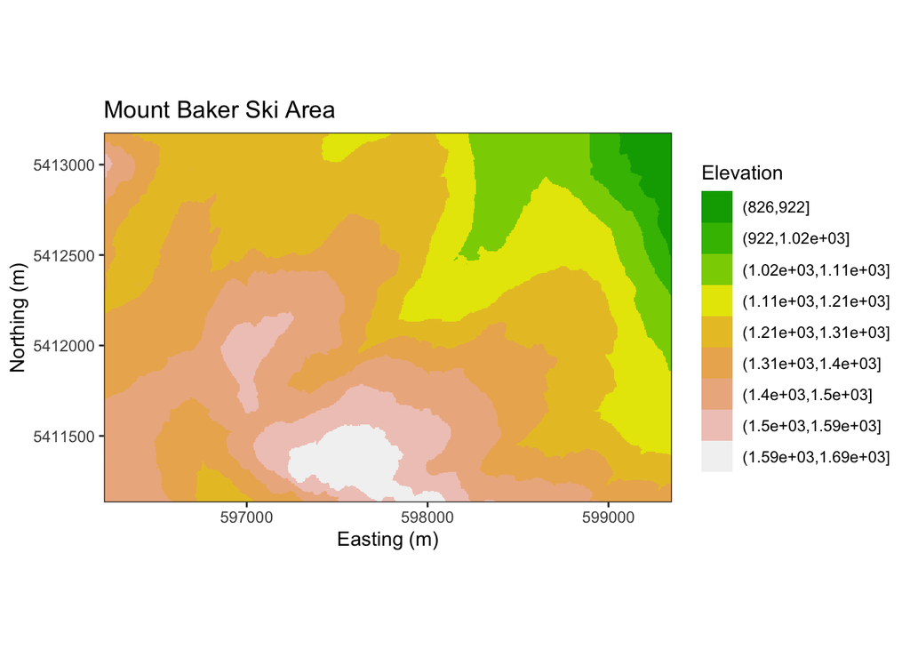

```r
ggplot() +
  geom_raster(data = mtbDEM_df , aes(x = x, y = y, fill = fct_elevation)) +
  scale_fill_manual(values = terrain.colors(9), name = "Elevation") + scale_x_continuous(expand = c(0, 0)) +
  scale_y_continuous(expand = c(0, 0)) +
  coord_quickmap(xlim = NULL, ylim = NULL, expand = TRUE, clip = "on") + coord_fixed() + theme_bw() + theme(panel.grid.major = element_blank(), panel.grid.minor = element_blank()) + labs(x = "Easting (m)", y = "Northing (m)", title = "Mount Baker Ski Area")
```

## Vector Data

### Gathering Information

After reading in the data file, it’s important to check that the CRS matches the raster’s, otherwise they will not layer on the same scale properly. The projection is also in UTM, and uses the same units as the above map. The bbox information, which shows the boundaries of this data, is within the dimensions of the map used above, so I won’t have to change anything before adding the chairlifts as a layer.

```r
chairs <- st_read("data/mtbChairLines.shp")
st_crs(chairs)
```

```
## Coordinate Reference System:
##   No user input
##   wkt:
## PROJCS["UTM_Zone_10_Northern_Hemisphere",
##     GEOGCS["GCS_GRS 1980(IUGG, 1980)",
##         DATUM["unknown",
##             SPHEROID["GRS80",6378137,298.257222101]],
##         PRIMEM["Greenwich",0],
##         UNIT["Degree",0.017453292519943295]],
##     PROJECTION["Transverse_Mercator"],
##     PARAMETER["latitude_of_origin",0],
##     PARAMETER["central_meridian",-123],
##     PARAMETER["scale_factor",0.9996],
##     PARAMETER["false_easting",500000],
##     PARAMETER["false_northing",0],
##     UNIT["Meter",1]]
```

```r
st_bbox(chairs)
```

```
##      xmin      ymin      xmax      ymax
##  596713.7 5411450.7  599131.5 5412970.1
```

### Map with Chairlift Lines

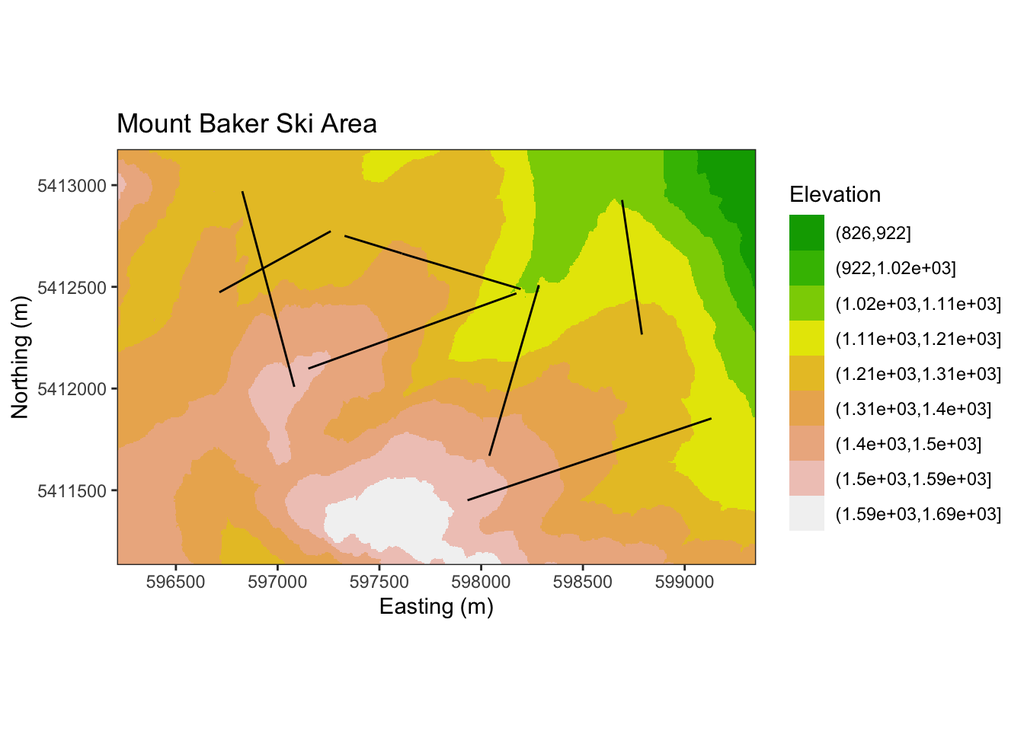

```r
ggplot() +
  geom_raster(data = mtbDEM_df , aes(x = x, y = y, fill = fct_elevation)) +
  scale_fill_manual(values = terrain.colors(9), name = "Elevation") + scale_x_continuous(expand = c(0, 0)) +
  scale_y_continuous(expand = c(0, 0)) +
  coord_quickmap(xlim = NULL, ylim = NULL, expand = TRUE, clip = "off") + coord_fixed() + theme_bw() + theme(panel.grid.major = element_blank(), panel.grid.minor = element_blank()) + labs(x = "Easting (m)", y = "Northing (m)", title = "Mount Baker Ski Area") + geom_sf(data = chairs) + coord_sf(datum = NULL)
```

This works, but it’s not that helpful without the chairlift labels. Unfortunately, the chairlift labels in their normal states overlap because they are placed at the ends of these vectors. One way around this is to find the center of the chairlift vectors, and attach the labels to the center rather than at the ends. This is accomplished using the st_centroid command, in the sf package, which is then put into its own dataframe. This label data set can then be added as a layer onto the map.

```r
st_centroid(chairs)
```

```
## Simple feature collection with 8 features and 1 field
## geometry type:  POINT
## dimension:      XY
## bbox:           xmin: 596953.9 ymin: 5411652 xmax: 598741 ymax: 5412708
## proj4string:    +proj=utm +zone=10 +ellps=GRS80 +units=m +no_defs
##   id                 geometry
## 1  1 POINT (596953.9 5412489)
## 2  2 POINT (596987.2 5412623)
## 3  3 POINT (597469.5 5412708)
## 4  6 POINT (597661.9 5412283)
## 5  4 POINT (597902.7 5412576)
## 6  5 POINT (598161.6 5412089)
## 7  7   POINT (598741 5412596)
## 8  8 POINT (598532.2 5411652)
```

```r
chairslabels <- st_centroid(chairs)
```

### Map with Labeled Chairlifts

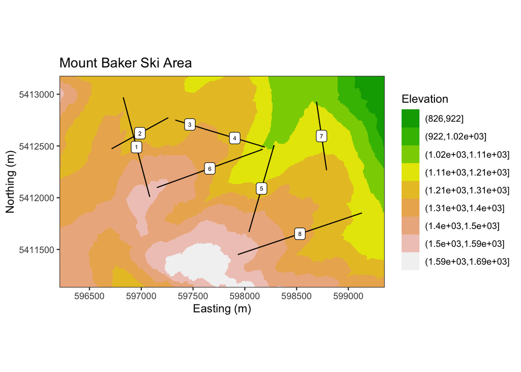

```r
ggplot() +
  geom_raster(data = mtbDEM_df , aes(x = x, y = y, fill = fct_elevation)) +
  scale_fill_manual(values = terrain.colors(9), name = "Elevation") + scale_x_continuous(expand = c(0, 0)) +
  scale_y_continuous(expand = c(0, 0)) +
  coord_quickmap(xlim = NULL, ylim = NULL, expand = TRUE, clip = "off") + coord_fixed() + theme_bw() + theme(panel.grid.major = element_blank(), panel.grid.minor = element_blank()) + labs(x = "Easting (m)", y = "Northing (m)", title = "Mount Baker Ski Area") + geom_sf(data = chairs) + coord_sf(datum = NULL) + geom_sf_label(mapping = aes( label = id), data = chairslabels, size=2) + coord_sf(datum = NULL)
```

## Adding Point Data (Lodges) to Map

```r
lodges <- read.csv("data/mtbLodges.csv")
str(lodges)
```

```
## 'data.frame':    3 obs. of  3 variables:
##  $ X : num  598733 596892 598253
##  $ Y : num  5412985 5412928 5412510
##  $ id: Factor w/ 3 levels "Heather Meadows Lodge",..: 3 1 2
```

```r
head(lodges)
```

```
##          X       Y                    id
## 1 598732.6 5412985    White Salmon Lodge
## 2 596891.9 5412928 Heather Meadows Lodge
## 3 598253.1 5412510           Raven's Hut
```

This last part is probably the easiest. Since, per the assignment instructions, this data is in UTM (the same as everything else), the points can be taken directly from the .csv file and placed as an additional layer onto the map.

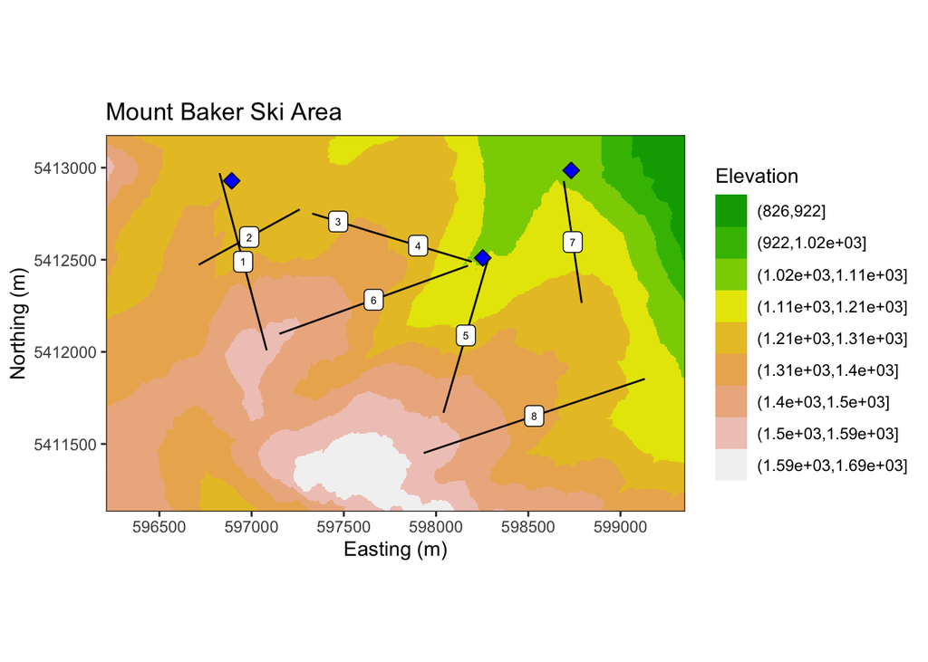

```r
ggplot() +
  geom_raster(data = mtbDEM_df , aes(x = x, y = y, fill = fct_elevation)) +
  scale_fill_manual(values = terrain.colors(9), name = "Elevation") + scale_x_continuous(expand = c(0, 0)) +
  scale_y_continuous(expand = c(0, 0)) +
  coord_quickmap(xlim = NULL, ylim = NULL, expand = TRUE, clip = "off") + coord_fixed() + theme_bw() + theme(panel.grid.major = element_blank(), panel.grid.minor = element_blank()) + labs(x = "Easting (m)", y = "Northing (m)", title = "Mount Baker Ski Area") + geom_sf(data = chairs) + coord_sf(datum = NULL) + geom_sf_label(mapping = aes( label = id), data = chairslabels, size=2) + coord_sf(datum = NULL) + geom_point(data = lodges, aes(x = X, y = Y), size = 3, pch= 23, fill = "blue")
```

## Final Product

The last step is adding the labels to the lodges. This is best achieved using the “geom_label_repel” option, found in the ggrepel package, which automatically prevents labels from overlapping one another.

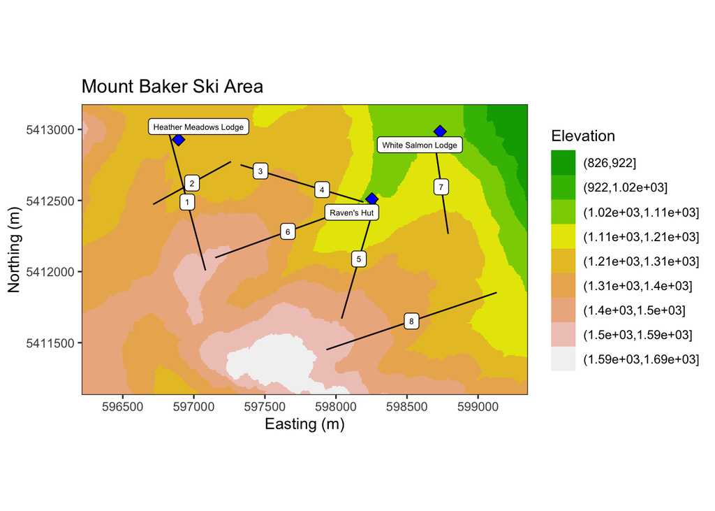

```r
ggplot() +
  geom_raster(data = mtbDEM_df , aes(x = x, y = y, fill = fct_elevation)) +
  scale_fill_manual(values = terrain.colors(9), name = "Elevation") + scale_x_continuous(expand = c(0, 0)) +
  scale_y_continuous(expand = c(0, 0)) +
  coord_quickmap(xlim = NULL, ylim = NULL, expand = TRUE, clip = "off") + coord_fixed() + theme_bw() + theme(panel.grid.major = element_blank(), panel.grid.minor = element_blank()) + labs(x = "Easting (m)", y = "Northing (m)", title = "Mount Baker Ski Area") + geom_sf(data = chairs) + coord_sf(datum = NULL) + geom_sf_label(mapping = aes( label = id), data = chairslabels, size=2) + coord_sf(datum = NULL) + geom_point(data = lodges, aes(x = X, y = Y), size = 3, pch= 23, fill = "blue") + geom_label_repel(data = lodges, aes(x = X, y = Y, label = id), size = 2)
```